# Analiza medijske pokrivenosti inflacije u Hrvatskoj

Eksploratorni pregled, konstrukcija indeksa i analiza prediktivnosti

Author

lux

Published

23. prosinca 2025.

# 1 Uvod

## 1.1 Motivacija i kontekst

Inflacija je tijekom 2022. i 2023. godine postala središnja tema ekonomske rasprave u Hrvatskoj i šire. Ovaj izvještaj nastoji odgovoriti na ključna pitanja:

- Kako se medijsko izvještavanje o inflaciji razvijalo kroz vrijeme?
- Je li medijska pozornost odgovarala stvarnim inflacijskim pritiscima?
- Može li se medijska pozornost koristiti kao prediktor ili rani indikator inflacije?
- Koje su teme i aspekti inflacije najzastupljeniji u medijima?

## 1.2 Struktura izvještaja

**Prikaži kod**

```r
dt <- as.data.table(read.xlsx(here("data", "inflacija_filtered.xlsx")))
if(is.numeric(dt$DATE)) {
  dt[, DATE := as.Date(DATE, origin = "1899-12-30")]
} else {
  dt[, DATE := as.Date(DATE)]
}

if("text_length" %in% names(dt)) {
  dt[, text_length := as.numeric(text_length)]
}
if("REACH" %in% names(dt)) {
  dt[, REACH := as.numeric(REACH)]
}
if("INTERACTIONS" %in% names(dt)) {
  dt[, INTERACTIONS := as.numeric(INTERACTIONS)]
}

# Dodaj AUTO_SENTIMENT ako ne postoji
if(!"AUTO_SENTIMENT" %in% names(dt)) {
  dt[, AUTO_SENTIMENT := fcase(
    stri_detect_regex(tolower(FULL_TEXT),
                     "kriza|katastrofa|strah|panika|pogoršanj|problem|visok.{1,20}inflacij",
                     case_insensitive = TRUE), -1,
    stri_detect_regex(tolower(FULL_TEXT),
                     "pad inflacije|usporavanje|stabilizacij|poboljšanj|nizak.{1,20}inflacij",
                     case_insensitive = TRUE), 1,
    default = 0
  )]
} else {
  dt[, AUTO_SENTIMENT := as.numeric(AUTO_SENTIMENT)]
}

dt[, `:=`(
  date = DATE,
  year = year(DATE),
  month = month(DATE),
  week = isoweek(DATE),
  yearmonth = floor_date(DATE, "month"),
  yearweek = floor_date(DATE, "week")
)]

dt <- dt[date <= as.Date("2024-11-01")]
```

# 2 Metodologija identifikacije članaka o inflaciji

## 2.1 Pregled procesa filtriranja

Identifikacija relevantnih članaka provedena je kroz **šestostupanjski proces filtriranja** koji kombinira strukturne kriterije, ključne riječi i kontekstualnu validaciju.

## 2.2 Pregled filtera

**Filter 1**: Tip izvora (samo web) **Filter 2**: Relevantni news portali (80+ verificiranih portala) **Filter 3**: Minimalna duljina teksta (>= 500 znakova) **Filter 4**: Naslov mora sadržavati inflacijske pojmove **Filter 5**: Core inflacijski pojmovi u tekstu **Filter 6**: Hrvatski kontekst (reference na hrvatsku ekonomiju)

Detaljni opis svakog filtera i regex uzoraka dostupan je u dokumentaciji projekta.

# 3 Eksploratorni pregled podataka

## 3.1 Osnovne statistike

**Prikaži kod**

```r
stats_summary <- data.table(
  Metrika = c(
    "Ukupan broj članaka",
    "Vremenski raspon",
    "Broj dana",
    "Prosječno članaka dnevno",
    "Broj izvora (portala)",
    "Broj kategorija izvora",
    "Članci sa sentimentom"
  ),
  Vrijednost = c(
    format(nrow(dt), big.mark = ","),
    paste(format(min(dt$date), "%d.%m.%Y"), "do", format(max(dt$date), "%d.%m.%Y")),
    as.character(as.numeric(max(dt$date) - min(dt$date))),
    round(nrow(dt) / as.numeric(max(dt$date) - min(dt$date)), 1),
    length(unique(dt$FROM)),
    length(unique(dt$source_category)),
    format(sum(!is.na(dt$AUTO_SENTIMENT)), big.mark = ",")
  )
)

kable(stats_summary, col.names = c("Metrika", "Vrijednost"),
      caption = "Osnovne statistike dataseta") %>%
  kable_styling(bootstrap_options = c("striped", "hover"), full_width = FALSE)
```

Osnovne statistike dataseta

| Metrika | Vrijednost |
| --- | --- |
| Ukupan broj članaka | 46,107 |
| Vremenski raspon | 01.01.2021 do 08.01.2024 |
| Broj dana | 1102 |
| Prosječno članaka dnevno | 41.8 |
| Broj izvora (portala) | 115 |
| Broj kategorija izvora | 5 |
| Članci sa sentimentom | 46,107 |

## 3.2 Distribucija po kategorijama izvora

**Prikaži kod**

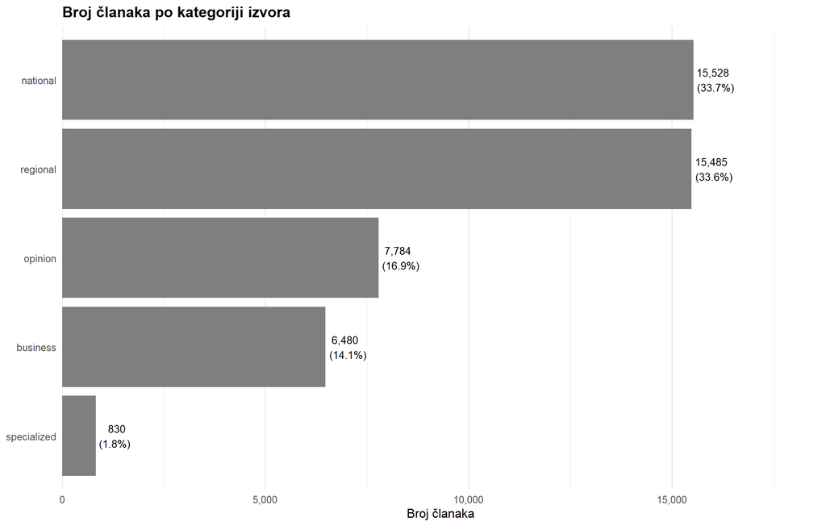

Distribucija članaka po kategorijama izvora

```r
cat_summary <- dt[, .(
  N = .N,
  Postotak = round(.N / nrow(dt) * 100, 1)
), by = source_category][order(-N)]

ggplot(cat_summary, aes(x = reorder(source_category, N), y = N, fill = source_category)) +
  geom_col(show.legend = FALSE) +
  geom_text(aes(label = paste0(format(N, big.mark = ","), "\n(", Postotak, "%)")),
            hjust = -0.1, size = 3.5) +
  coord_flip() +
  scale_y_continuous(labels = comma, expand = expansion(mult = c(0, 0.2))) +
  scale_fill_manual(values = c("national" = colors_gimes["primary"],
                               "business" = colors_gimes["accent"],
                               "regional" = colors_gimes["success"],
                               "specialized" = colors_gimes["warning"],
                               "opinion" = colors_gimes["secondary"])) +
  labs(
    title = "Broj članaka po kategoriji izvora",
    x = NULL,
    y = "Broj članaka"
  ) +
  theme(
    plot.title = element_text(face = "bold"),
    panel.grid.major.y = element_blank()
  )
```

## 3.3 Top 20 izvora

**Prikaži kod**

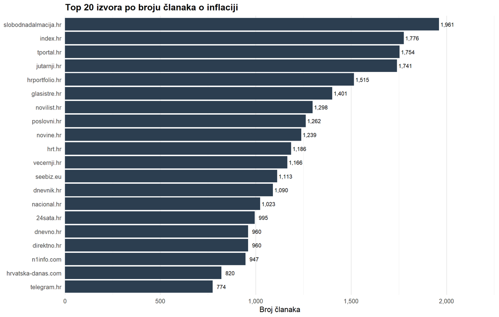

20 najaktivnijih izvora

```r
top_sources <- dt[, .(N = .N), by = FROM][order(-N)][1:20]

ggplot(top_sources, aes(x = reorder(FROM, N), y = N)) +
  geom_col(fill = colors_gimes["primary"]) +
  geom_text(aes(label = format(N, big.mark = ",")), hjust = -0.1, size = 3) +
  coord_flip() +
  scale_y_continuous(labels = comma, expand = expansion(mult = c(0, 0.15))) +
  labs(
    title = "Top 20 izvora po broju članaka o inflaciji",
    x = NULL,
    y = "Broj članaka"
  ) +
  theme(
    plot.title = element_text(face = "bold"),
    panel.grid.major.y = element_blank()
  )
```

## 3.4 Distribucija duljine teksta

**Prikaži kod**

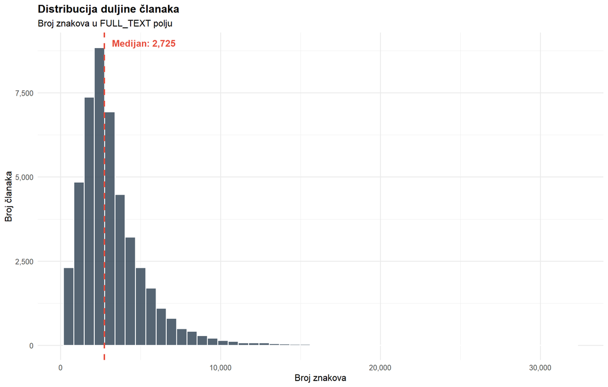

Distribucija duljine članaka

```r
if("text_length" %in% names(dt)) {
  ggplot(dt, aes(x = text_length)) +
    geom_histogram(bins = 50, fill = colors_gimes["primary"], alpha = 0.8, color = "white") +
    geom_vline(xintercept = median(dt$text_length, na.rm = TRUE),
               color = colors_gimes["secondary"], linetype = "dashed", linewidth = 1) +
    annotate("text", x = median(dt$text_length, na.rm = TRUE) + 500,
             y = Inf, vjust = 2, hjust = 0,
             label = paste("Medijan:", format(round(median(dt$text_length, na.rm = TRUE)), big.mark = ",")),
             color = colors_gimes["secondary"], fontface = "bold") +
    scale_x_continuous(labels = comma) +
    scale_y_continuous(labels = comma) +
    labs(
      title = "Distribucija duljine članaka",
      subtitle = "Broj znakova u FULL_TEXT polju",
      x = "Broj znakova",
      y = "Broj članaka"
    ) +
    theme(plot.title = element_text(face = "bold"))
}
```

# 4 Vremenska analiza

## 4.1 Dnevna frekvencija članaka o inflaciji

**Prikaži kod**

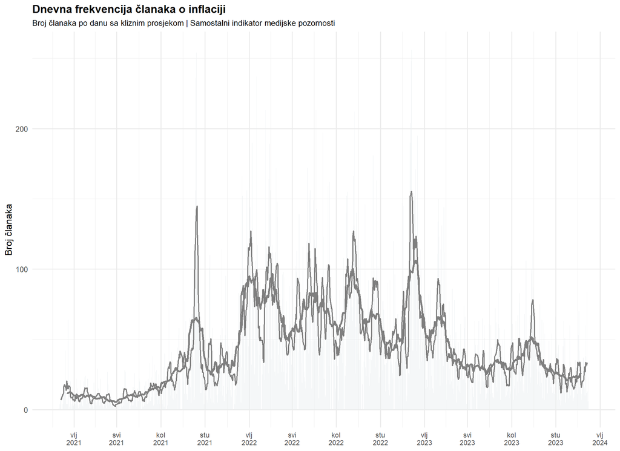

Dnevni broj članaka o inflaciji

```r
daily <- dt[, .(N = .N), by = date][order(date)]
daily[, MA7 := frollmean(N, n = 7, align = "center")]
daily[, MA30 := frollmean(N, n = 30, align = "center")]

ggplot(daily, aes(x = date)) +
  geom_col(aes(y = N), fill = colors_gimes["light"], alpha = 0.5, width = 1) +
  geom_line(aes(y = MA7, color = "7-dnevni prosjek"), linewidth = 0.8, na.rm = TRUE) +
  geom_line(aes(y = MA30, color = "30-dnevni prosjek"), linewidth = 1.2, na.rm = TRUE) +
  scale_x_date(date_breaks = "3 months", date_labels = "%b\n%Y") +
  scale_y_continuous(labels = comma) +
  scale_color_manual(values = c("7-dnevni prosjek" = colors_gimes["accent"],
                                "30-dnevni prosjek" = colors_gimes["secondary"])) +
  labs(
    title = "Dnevna frekvencija članaka o inflaciji",
    subtitle = "Broj članaka po danu sa kliznim prosjekom | Samostalni indikator medijske pozornosti",
    x = NULL,
    y = "Broj članaka",
    color = "Klizni prosjek"
  ) +
  theme(
    plot.title = element_text(face = "bold", size = 14),
    plot.subtitle = element_text(size = 10),
    legend.position = "bottom",
    axis.text.x = element_text(size = 9)
  )
```

## 4.2 Mjesečna dinamika

**Prikaži kod**

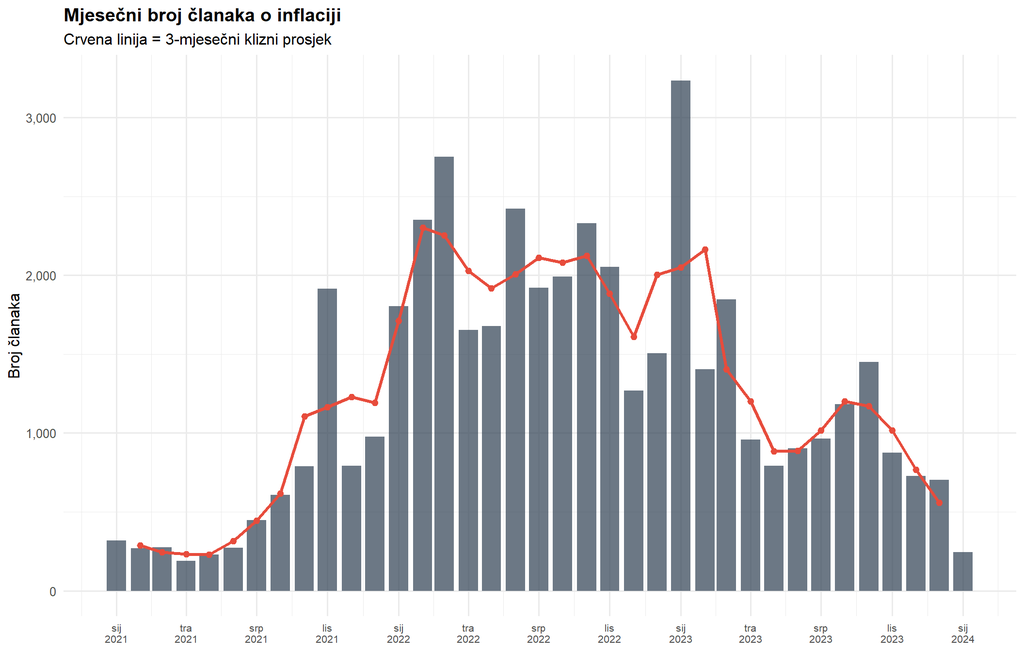

Mjesečni broj članaka o inflaciji

```r
monthly <- dt[, .(N = .N), by = yearmonth][order(yearmonth)]
monthly[, MA3 := frollmean(N, n = 3, align = "center")]

p_monthly <- ggplot(monthly, aes(x = yearmonth)) +
  geom_col(aes(y = N), fill = colors_gimes["primary"], alpha = 0.7, width = 25) +
  geom_line(aes(y = MA3), color = colors_gimes["secondary"], linewidth = 1.2, na.rm = TRUE) +
  geom_point(aes(y = MA3), color = colors_gimes["secondary"], size = 2, na.rm = TRUE) +
  scale_x_date(date_breaks = "3 months", date_labels = "%b\n%Y") +
  scale_y_continuous(labels = comma) +
  labs(
    title = "Mjesečni broj članaka o inflaciji",
    subtitle = "Crvena linija = 3-mjesečni klizni prosjek",
    x = NULL,
    y = "Broj članaka"
  ) +
  theme(
    plot.title = element_text(face = "bold"),
    axis.text.x = element_text(size = 8)
  )

p_monthly
```

## 4.3 Tjedna dinamika

**Prikaži kod**

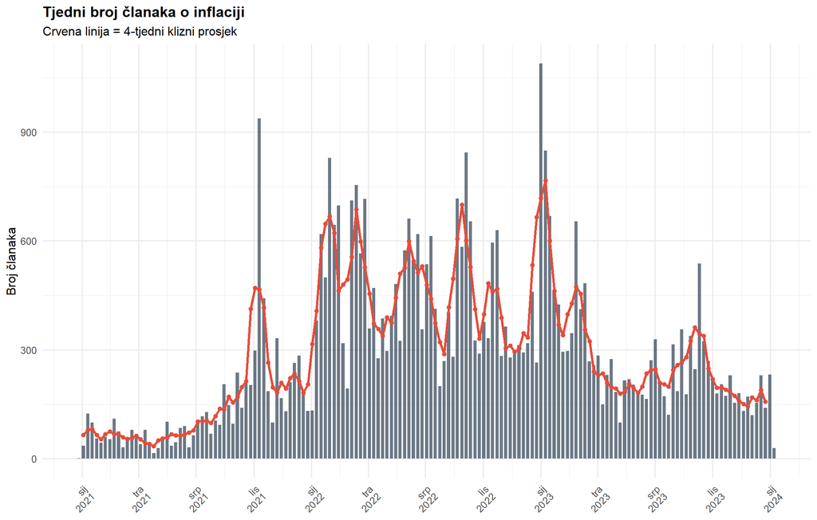

Tjedni broj članaka o inflaciji

```r
weekly <- dt[, .(N = .N), by = yearweek][order(yearweek)]
weekly[, MA4 := frollmean(N, n = 4, align = "center")]

ggplot(weekly, aes(x = yearweek)) +
  geom_col(aes(y = N), fill = colors_gimes["primary"], alpha = 0.7, width = 5) +
  geom_line(aes(y = MA4), color = colors_gimes["secondary"], linewidth = 1.2, na.rm = TRUE) +
  geom_point(aes(y = MA4), color = colors_gimes["secondary"], size = 1.5, na.rm = TRUE) +
  scale_x_date(date_breaks = "3 months", date_labels = "%b\n%Y") +
  scale_y_continuous(labels = comma) +
  labs(
    title = "Tjedni broj članaka o inflaciji",
    subtitle = "Crvena linija = 4-tjedni klizni prosjek",
    x = NULL,
    y = "Broj članaka"
  ) +
  theme(
    plot.title = element_text(face = "bold"),
    axis.text.x = element_text(angle = 45, hjust = 1)
  )
```

## 4.4 Godišnja usporedba

**Prikaži kod**

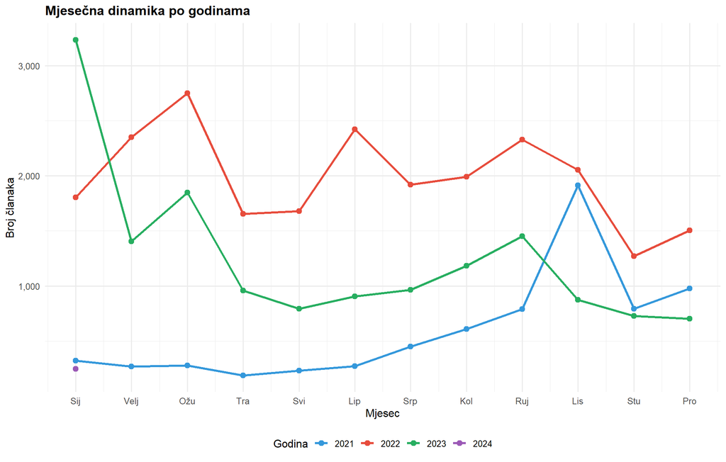

Usporedba mjesečne dinamike po godinama

```r
yearly_monthly <- dt[, .(N = .N), by = .(year, month)][order(year, month)]

ggplot(yearly_monthly, aes(x = month, y = N, color = factor(year), group = year)) +
  geom_line(linewidth = 1.2) +
  geom_point(size = 2.5) +
  scale_x_continuous(breaks = 1:12, labels = c("Sij", "Velj", "Ožu", "Tra", "Svi", "Lip",
                                                "Srp", "Kol", "Ruj", "Lis", "Stu", "Pro")) +
  scale_y_continuous(labels = comma) +
  scale_color_manual(values = c("2021" = "#3498DB", "2022" = "#E74C3C",
                                "2023" = "#27AE60", "2024" = "#9B59B6")) +
  labs(
    title = "Mjesečna dinamika po godinama",
    x = "Mjesec",
    y = "Broj članaka",
    color = "Godina"
  ) +
  theme(
    plot.title = element_text(face = "bold"),
    legend.position = "bottom"
  )
```

## 4.5 Distribucija po danima u tjednu

**Prikaži kod**

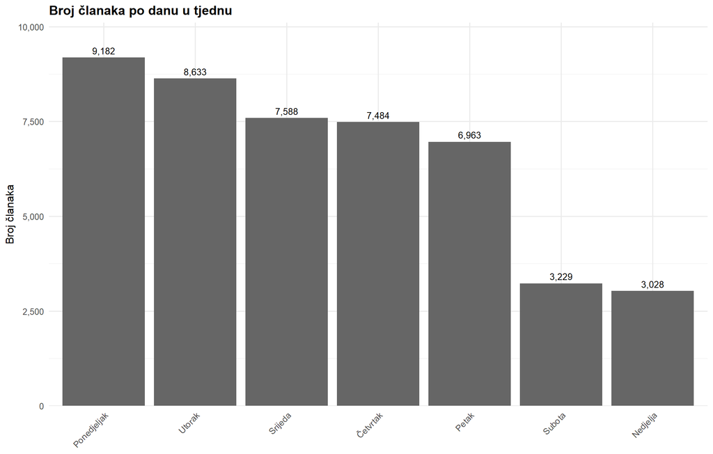

Distribucija članaka po danima u tjednu

```r
dt[, weekday_num := wday(date, week_start = 1)]
weekday_labels <- c("Ponedjeljak", "Utorak", "Srijeda", "Četvrtak", "Petak", "Subota", "Nedjelja")
dt[, weekday := factor(weekday_num, levels = 1:7, labels = weekday_labels)]

weekday_summary <- dt[, .(N = .N), by = weekday][order(weekday)]

ggplot(weekday_summary, aes(x = weekday, y = N)) +
  geom_col(fill = "gray40", show.legend = FALSE) +
  geom_text(aes(label = format(N, big.mark = ",")), vjust = -0.5, size = 3.5) +
  scale_y_continuous(labels = comma, expand = expansion(mult = c(0, 0.1))) +
  labs(
    title = "Broj članaka po danu u tjednu",
    x = NULL,
    y = "Broj članaka"
  ) +
  theme(
    plot.title = element_text(face = "bold"),
    axis.text.x = element_text(angle = 45, hjust = 1)
  )
```

## 4.6 Sentiment kroz vrijeme

**Prikaži kod**

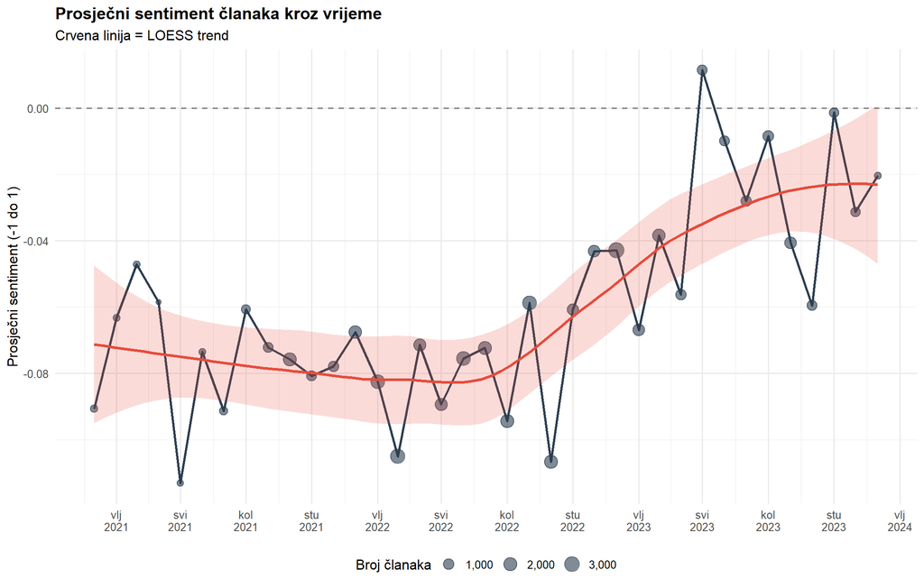

Dinamika sentimenta kroz vrijeme

```r
if("AUTO_SENTIMENT" %in% names(dt)) {
  sentiment_monthly <- dt[!is.na(AUTO_SENTIMENT), .(
    avg_sentiment = mean(AUTO_SENTIMENT),
    N = .N,
    pct_negative = sum(AUTO_SENTIMENT == -1) / .N * 100,
    pct_positive = sum(AUTO_SENTIMENT == 1) / .N * 100
  ), by = yearmonth][order(yearmonth)]

  ggplot(sentiment_monthly, aes(x = yearmonth)) +
    geom_hline(yintercept = 0, color = "gray50", linetype = "dashed") +
    geom_line(aes(y = avg_sentiment), color = colors_gimes["primary"], linewidth = 1) +
    geom_point(aes(y = avg_sentiment, size = N), color = colors_gimes["primary"], alpha = 0.6) +
    geom_smooth(aes(y = avg_sentiment), method = "loess", se = TRUE,
                color = colors_gimes["secondary"], fill = colors_gimes["secondary"], alpha = 0.2) +
    scale_x_date(date_breaks = "3 months", date_labels = "%b\n%Y") +
    scale_size_continuous(range = c(2, 6), labels = comma) +
    labs(
      title = "Prosječni sentiment članaka kroz vrijeme",
      subtitle = "Crvena linija = LOESS trend",
      x = NULL,
      y = "Prosječni sentiment (-1 do 1)",
      size = "Broj članaka"
    ) +
    theme(
      plot.title = element_text(face = "bold"),
      legend.position = "bottom"
    )
}
```

# 5 Dnevni broj spominjanja inflacije kao samostalni indikator

Dnevni broj članaka o inflaciji predstavlja jednostavan ali informativan pokazatelj medijske pozornosti na inflacijske teme. Ovaj indikator može služiti kao real-time proxy za javnu percepciju inflacijskih pritisaka u Hrvatskoj.

## 5.1 Metodologija

Indikator se temelji na jednostavnom brojanju članaka koji zadovoljavaju kriterije filtriranja za inflacijsku tematiku. Za izglađivanje dnevnih fluktuacija koristi se 30-dnevni klizni prosjek koji daje stabilniju sliku trenda medijske pozornosti.

## 5.2 Dnevni indikator medijske pozornosti na inflaciju

**Prikaži kod**

[figure not shown]

Dnevni broj spominjanja inflacije kao samostalni indikator

```r
# Izračunaj statistike za anotacije
peak_date <- daily[which.max(MA30), date]
peak_value <- daily[which.max(MA30), MA30]
avg_value <- mean(daily$MA30, na.rm = TRUE)

# Identificiraj ključne periode
daily[, period := fcase(
  date < as.Date("2022-01-01"), "Pred-inflacijski period",
  date >= as.Date("2022-01-01") & date < as.Date("2023-07-01"), "Inflacijski vrhunac",
  date >= as.Date("2023-07-01"), "Normalizacija"
)]

ggplot(daily, aes(x = date)) +
  # Pozadinske zone za periode
  geom_rect(aes(xmin = as.Date("2022-01-01"), xmax = as.Date("2023-07-01"),
                ymin = -Inf, ymax = Inf), fill = colors_gimes["secondary"], alpha = 0.1) +
  # Dnevni podaci kao stupci
  geom_col(aes(y = N), fill = "gray80", alpha = 0.4, width = 1) +
  # Klizni prosjeci
  geom_line(aes(y = MA7), color = colors_gimes["accent"], linewidth = 0.6, alpha = 0.6, na.rm = TRUE) +
  geom_line(aes(y = MA30), color = colors_gimes["primary"], linewidth = 1.3, na.rm = TRUE) +
  # Horizontalna linija za prosjek
  geom_hline(yintercept = avg_value, color = colors_gimes["warning"], linetype = "dashed", linewidth = 0.8) +
  # Anotacija za vrhunac
  annotate("point", x = peak_date, y = peak_value, color = colors_gimes["secondary"], size = 4) +
  annotate("text", x = peak_date, y = peak_value + 3,
           label = paste0("Vrhunac: ", format(peak_date, "%d.%m.%Y")),
           color = colors_gimes["secondary"], fontface = "bold", size = 3.5, hjust = 0) +
  # Anotacija za prosjek
  annotate("text", x = min(daily$date) + 30, y = avg_value + 2,
           label = paste0("Prosjek: ", round(avg_value, 1), " članaka/dan"),
           color = colors_gimes["warning"], fontface = "bold", size = 3.5, hjust = 0) +
  # Anotacije za periode
  annotate("text", x = as.Date("2022-10-01"), y = max(daily$N, na.rm = TRUE) * 0.95,
           label = "Inflacijski vrhunac", color = colors_gimes["secondary"],
           fontface = "italic", size = 3.5) +
  scale_x_date(date_breaks = "3 months", date_labels = "%b\n%Y") +
  scale_y_continuous(labels = comma, expand = expansion(mult = c(0, 0.05))) +
  labs(
    title = "Dnevni broj spominjanja inflacije u hrvatskim medijima",
    subtitle = "Samostalni indikator medijske pozornosti | Tamna linija = 30-dnevni MA | Svijetla linija = 7-dnevni MA",
    x = NULL,
    y = "Broj članaka"
  ) +
  theme(
    plot.title = element_text(face = "bold", size = 14),
    plot.subtitle = element_text(size = 10, color = "gray40"),
    panel.grid.minor = element_blank(),
    axis.text.x = element_text(size = 9)
  )
```

## 5.3 Normalizirani dnevni indikator (0-100)

**Prikaži kod**

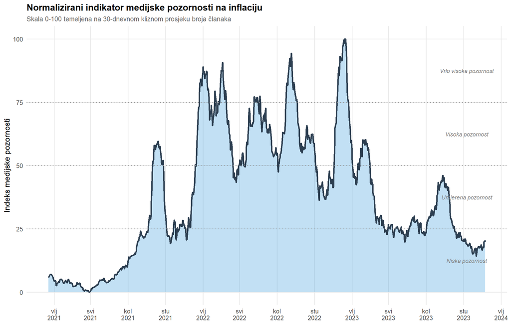

Normalizirani dnevni indikator medijske inflacije

```r
# Normaliziraj 30-dnevni MA na skalu 0-100
daily[, MA30_norm := (MA30 - min(MA30, na.rm = TRUE)) /
        (max(MA30, na.rm = TRUE) - min(MA30, na.rm = TRUE)) * 100]

ggplot(daily[!is.na(MA30_norm)], aes(x = date)) +
  geom_ribbon(aes(ymin = 0, ymax = MA30_norm), fill = colors_gimes["accent"], alpha = 0.3) +
  geom_line(aes(y = MA30_norm), color = colors_gimes["primary"], linewidth = 1.2) +
  # Zone intenziteta
  geom_hline(yintercept = c(25, 50, 75), linetype = "dotted", color = "gray60") +
  annotate("text", x = max(daily$date) - 60, y = 12.5, label = "Niska pozornost",
           color = "gray50", size = 3, fontface = "italic") +
  annotate("text", x = max(daily$date) - 60, y = 37.5, label = "Umjerena pozornost",
           color = "gray50", size = 3, fontface = "italic") +
  annotate("text", x = max(daily$date) - 60, y = 62.5, label = "Visoka pozornost",
           color = "gray50", size = 3, fontface = "italic") +
  annotate("text", x = max(daily$date) - 60, y = 87.5, label = "Vrlo visoka pozornost",
           color = "gray50", size = 3, fontface = "italic") +
  scale_x_date(date_breaks = "3 months", date_labels = "%b\n%Y") +
  scale_y_continuous(limits = c(0, 100), breaks = seq(0, 100, 25)) +
  labs(
    title = "Normalizirani indikator medijske pozornosti na inflaciju",
    subtitle = "Skala 0-100 temeljena na 30-dnevnom kliznom prosjeku broja članaka",
    x = NULL,
    y = "Indeks medijske pozornosti"
  ) +
  theme(
    plot.title = element_text(face = "bold", size = 14),
    plot.subtitle = element_text(size = 10, color = "gray40"),
    panel.grid.minor = element_blank()
  )
```

## 5.4 Statistike dnevnog indikatora

**Prikaži kod**

```r
daily_stats <- data.table(
  Metrika = c(
    "Prosječan broj članaka dnevno",
    "Medijan članaka dnevno",
    "Maksimalan broj članaka (jedan dan)",
    "Datum maksimuma",
    "Standardna devijacija",
    "Prosječni 30-dnevni MA",
    "Maksimalni 30-dnevni MA",
    "Datum vrhunca (30-dnevni MA)"
  ),
  Vrijednost = c(
    round(mean(daily$N), 1),
    round(median(daily$N), 1),
    max(daily$N),
    format(daily[which.max(N), date], "%d.%m.%Y"),
    round(sd(daily$N), 1),
    round(mean(daily$MA30, na.rm = TRUE), 1),
    round(max(daily$MA30, na.rm = TRUE), 1),
    format(daily[which.max(MA30), date], "%d.%m.%Y")
  )
)

kable(daily_stats, caption = "Statistike dnevnog indikatora medijske pozornosti") %>%
  kable_styling(bootstrap_options = c("striped", "hover"), full_width = FALSE)
```

Statistike dnevnog indikatora medijske pozornosti

| Metrika | Vrijednost |
| --- | --- |
| Prosječan broj članaka dnevno | 43.5 |
| Medijan članaka dnevno | 30 |
| Maksimalan broj članaka (jedan dan) | 256 |
| Datum maksimuma | 05.01.2023 |
| Standardna devijacija | 42.2 |
| Prosječni 30-dnevni MA | 44.1 |
| Maksimalni 30-dnevni MA | 106.1 |
| Datum vrhunca (30-dnevni MA) | 16.01.2023 |

# 6 GIMES Indeks medijske inflacije

## 6.1 Metodologija

GIMES indeks (Government-Industry-Media Economic Sentiment) medijske inflacije konstruiran je kao kompozitni pokazatelj koji kombinira četiri dimenzije medijskog izvještavanja:

### 6.1.1 Komponente indeksa

1. **Volumen (40% težina)**
   - Broj članaka o inflaciji u mjesecu
   - Normaliziran na skalu 0-100
   - Veći broj članaka = veća medijska pozornost
2. **Intenzitet (20% težina)**
   - Prosječna duljina članaka (broj znakova)
   - Odražava dubinu analize
   - Duži članci = detaljnije izvještavanje
3. **Sentiment (20% težina)**
   - Prosječni sentiment članaka (invertiran)
   - -1 (negativan), 0 (neutralan), 1 (pozitivan)
   - Negativniji sentiment = veća zabrinutost = viši indeks
4. **Doseg (20% težina)**
   - Prosječni reach/interakcije ako dostupno
   - Inače zamijenjeno prosječnom vrijednosti (50)

### 6.1.2 Formula

$$GIMES = 0.4 \times V_{norm} + 0.2 \times I_{norm} + 0.2 \times (100 - S_{norm}) + 0.2 \times R_{norm}$$

gdje su: - $V_{norm}$ = normalizirani volumen - $I_{norm}$ = normalizirani intenzitet - $S_{norm}$ = normalizirani sentiment (invertiran) - $R_{norm}$ = normalizirani doseg

Indeks je skaliran na raspon **0-100**, gdje viša vrijednost indicira veću medijsku pozornost i zabrinutost oko inflacije.

**Prikaži kod**

```r
index_data <- dt[, .(
  volume = .N,
  avg_length = mean(text_length, na.rm = TRUE),
  avg_sentiment = mean(AUTO_SENTIMENT, na.rm = TRUE),
  avg_reach = if("REACH" %in% names(.SD)) mean(REACH, na.rm = TRUE) else NA_real_,
  total_reach = if("REACH" %in% names(.SD)) sum(REACH, na.rm = TRUE) else NA_real_,
  avg_interactions = if("INTERACTIONS" %in% names(.SD)) mean(INTERACTIONS, na.rm = TRUE) else NA_real_
), by = yearmonth][order(yearmonth)]

normalize <- function(x) {
  if(all(is.na(x))) return(rep(50, length(x)))
  min_x <- min(x, na.rm = TRUE)
  max_x <- max(x, na.rm = TRUE)
  if(max_x == min_x) return(rep(50, length(x)))
  (x - min_x) / (max_x - min_x) * 100
}

index_data[, `:=`(
  volume_norm = normalize(volume),
  length_norm = normalize(avg_length),
  sentiment_norm = normalize(avg_sentiment),
  reach_norm = normalize(avg_reach)
)]

index_data[, gimes_index :=
  0.40 * volume_norm +
  0.20 * length_norm +
  0.20 * (100 - sentiment_norm) +
  0.20 * fifelse(is.na(reach_norm), 50, reach_norm)
]

index_data[, gimes_index_ma3 := frollmean(gimes_index, n = 3, align = "center")]
index_data[, gimes_yoy := (gimes_index / shift(gimes_index, 12) - 1) * 100]
```

## 6.2 GIMES Indeks kroz vrijeme

**Prikaži kod**

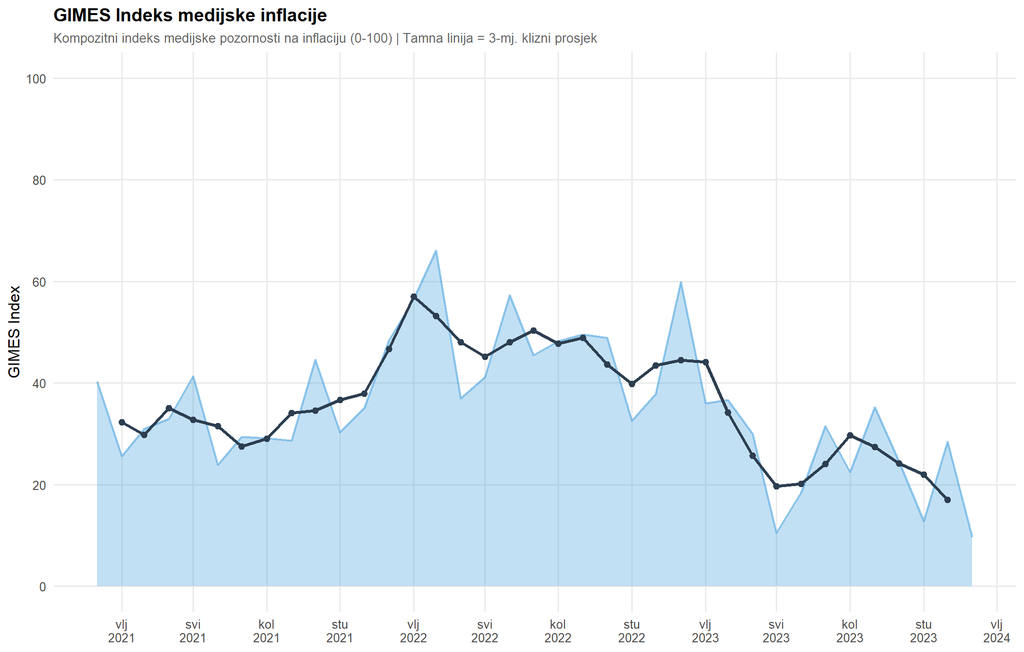

GIMES Indeks medijske inflacije

```r
p_index <- ggplot(index_data, aes(x = yearmonth)) +
  geom_ribbon(aes(ymin = 0, ymax = gimes_index), fill = colors_gimes["accent"], alpha = 0.3) +
  geom_line(aes(y = gimes_index), color = colors_gimes["accent"], linewidth = 0.8, alpha = 0.5) +
  geom_line(aes(y = gimes_index_ma3), color = colors_gimes["primary"], linewidth = 1.2, na.rm = TRUE) +
  geom_point(aes(y = gimes_index_ma3), color = colors_gimes["primary"], size = 2, na.rm = TRUE) +
  scale_x_date(date_breaks = "3 months", date_labels = "%b\n%Y") +
  scale_y_continuous(limits = c(0, 100), breaks = seq(0, 100, 20)) +
  labs(
    title = "GIMES Indeks medijske inflacije",
    subtitle = "Kompozitni indeks medijske pozornosti na inflaciju (0-100) | Tamna linija = 3-mj. klizni prosjek",
    x = NULL,
    y = "GIMES Index"
  ) +
  theme(
    plot.title = element_text(face = "bold", size = 14),
    plot.subtitle = element_text(size = 10, color = "gray40"),
    panel.grid.minor = element_blank()
  )

p_index
```

## 6.3 Komponente indeksa

**Prikaži kod**

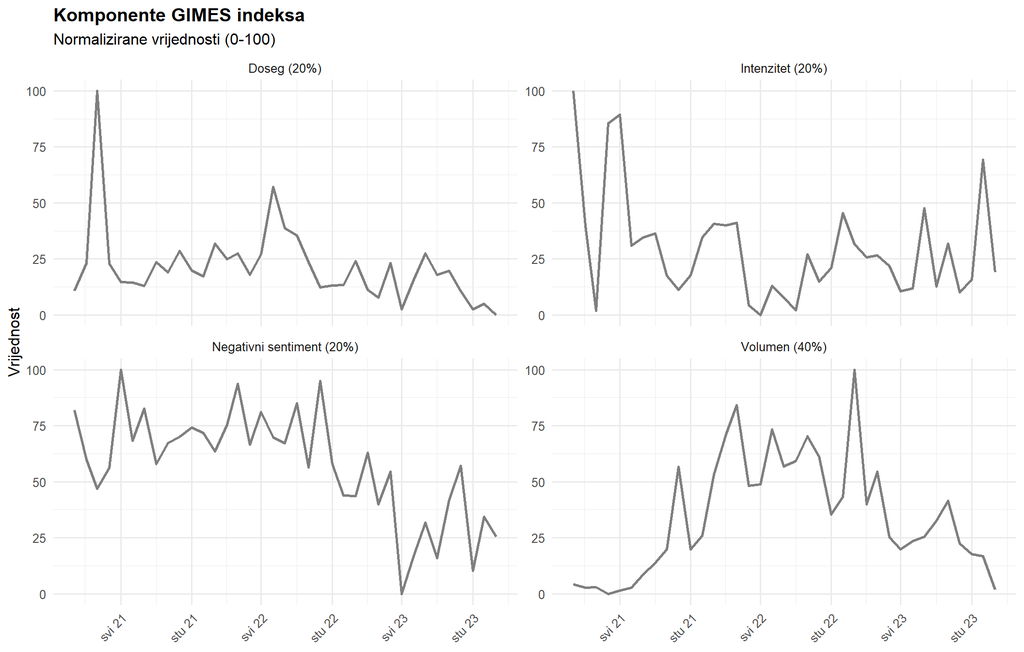

Komponente GIMES indeksa

```r
components_long <- melt(
  index_data[, .(yearmonth, volume_norm, length_norm,
                 sentiment_inv = 100 - sentiment_norm, reach_norm)],
  id.vars = "yearmonth",
  variable.name = "component",
  value.name = "value"
)

component_labels <- c(
  "volume_norm" = "Volumen (40%)",
  "length_norm" = "Intenzitet (20%)",
  "sentiment_inv" = "Negativni sentiment (20%)",
  "reach_norm" = "Doseg (20%)"
)

components_long[, component_label := component_labels[as.character(component)]]

ggplot(components_long, aes(x = yearmonth, y = value, color = component_label)) +
  geom_line(linewidth = 1) +
  facet_wrap(~component_label, ncol = 2, scales = "free_y") +
  scale_x_date(date_breaks = "6 months", date_labels = "%b %y") +
  scale_color_manual(values = c(
    "Volumen (40%)" = colors_gimes["primary"],
    "Intenzitet (20%)" = colors_gimes["accent"],
    "Negativni sentiment (20%)" = colors_gimes["secondary"],
    "Doseg (20%)" = colors_gimes["success"]
  )) +
  labs(
    title = "Komponente GIMES indeksa",
    subtitle = "Normalizirane vrijednosti (0-100)",
    x = NULL,
    y = "Vrijednost",
    color = NULL
  ) +
  theme(
    plot.title = element_text(face = "bold"),
    legend.position = "none",
    axis.text.x = element_text(angle = 45, hjust = 1)
  )
```

## 6.4 Tablica indeksa

**Prikaži kod**

```r
index_table <- index_data[, .(
  Mjesec = format(yearmonth, "%b %Y"),
  `Broj članaka` = format(volume, big.mark = ","),
  `GIMES Index` = round(gimes_index, 1),
  `Klizni prosjek` = round(gimes_index_ma3, 1),
  `YoY promjena (%)` = ifelse(is.na(gimes_yoy), "-", paste0(ifelse(gimes_yoy > 0, "+", ""), round(gimes_yoy, 1)))
)]

kable(tail(index_table, 12),
      caption = "GIMES Indeks - zadnjih 12 mjeseci",
      align = c("l", "r", "r", "r", "r")) %>%
  kable_styling(bootstrap_options = c("striped", "hover", "condensed"), full_width = FALSE) %>%
  row_spec(0, bold = TRUE, background = colors_gimes["primary"], color = "white")
```

GIMES Indeks - zadnjih 12 mjeseci

| Mjesec | Broj članaka | GIMES Index | Klizni prosjek | YoY promjena (%) |
| --- | --- | --- | --- | --- |
| vlj 2023 | 1,405 | 36.0 | 44.2 | -36.3 |
| ožu 2023 | 1,848 | 36.7 | 34.2 | -44.5 |
| tra 2023 | 959 | 30.0 | 25.7 | -18.9 |
| svi 2023 | 793 | 10.6 | 19.7 | -74.3 |
| lip 2023 | 904 | 18.4 | 20.2 | -67.9 |
| srp 2023 | 964 | 31.6 | 24.1 | -30.6 |
| kol 2023 | 1,184 | 22.4 | 29.7 | -53.5 |
| ruj 2023 | 1,451 | 35.3 | 27.4 | -28.8 |
| lis 2023 | 874 | 24.5 | 24.2 | -49.9 |
| stu 2023 | 728 | 12.8 | 21.9 | -60.7 |
| pro 2023 | 702 | 28.4 | 17.0 | -24.9 |
| sij 2024 | 246 | 9.7 | NA | -83.8 |

# 7 Validacija sa službenim podacima

## 7.1 Dohvaćanje službenih podataka

**Prikaži kod**

```r
message("Dohvaćanje HICP podataka iz Eurostata...")

eurostat_headline <- NULL
eurostat_core <- NULL

tryCatch({
  hicp_data <- get_eurostat("prc_hicp_manr",
                            filters = list(geo = "HR",
                                          coicop = "CP00",
                                          unit = "RCH_A"),
                            time_format = "date")

  setDT(hicp_data)
  eurostat_headline <<- hicp_data[time >= "2021-01-01" & time <= "2024-11-01",
                                   .(yearmonth = time, eurostat_hicp = values)]

  core_data <- get_eurostat("prc_hicp_manr",
                           filters = list(geo = "HR",
                                         coicop = "CP00XEF",
                                         unit = "RCH_A"),
                           time_format = "date")

  setDT(core_data)
  eurostat_core <<- core_data[time >= "2021-01-01" & time <= "2024-11-01",
                              .(yearmonth = time, eurostat_core = values)]

  message("Uspješno dohvaćeno ", nrow(eurostat_headline), " mjeseci Eurostat podataka")

}, error = function(e) {
  message("UPOZORENJE: Ne mogu se spojiti na Eurostat. Koristim backup podatke.")
  message("Greška: ", e$message)

  eurostat_headline <<- data.table(
    yearmonth = seq(as.Date("2021-01-01"), as.Date("2024-11-01"), by = "month"),
    eurostat_hicp = c(
      0.2, 0.6, 0.8, 1.9, 2.4, 2.3, 2.6, 3.0, 3.3, 3.8, 4.8, 5.5,
      5.8, 6.3, 7.3, 9.4, 10.8, 12.1, 12.3, 12.4, 12.8, 13.0, 13.0, 12.7,
      12.0, 11.1, 10.5, 9.2, 8.4, 8.2, 7.3, 7.7, 7.1, 5.3, 4.9, 4.7,
      4.3, 4.0, 3.9, 3.7, 3.6, 3.4, 3.2, 2.9, 2.8, 2.6, 2.4
    )
  )

  eurostat_core <<- data.table(
    yearmonth = seq(as.Date("2021-01-01"), as.Date("2024-11-01"), by = "month"),
    eurostat_core = c(
      0.5, 0.8, 1.0, 1.5, 1.8, 1.9, 2.0, 2.2, 2.4, 2.7, 3.2, 3.8,
      4.2, 4.8, 5.6, 6.8, 7.9, 8.7, 8.9, 9.1, 9.4, 9.8, 10.2, 10.5,
      10.8, 10.5, 10.0, 9.2, 8.5, 8.0, 7.2, 7.4, 7.0, 6.2, 5.8, 5.5,
      5.2, 4.9, 4.6, 4.3, 4.1, 3.8, 3.5, 3.3, 3.2, 3.0, 2.9
    )
  )
})

dzs_inflation <- data.table(
  yearmonth = seq(as.Date("2021-01-01"), as.Date("2024-11-01"), by = "month"),
  dzs_cpi = c(
    0.1, 0.5, 0.7, 1.8, 2.3, 2.2, 2.5, 2.9, 3.2, 3.7, 4.7, 5.4,
    5.7, 6.2, 7.2, 9.3, 10.7, 12.0, 12.2, 12.3, 12.7, 12.9, 12.9, 12.6,
    11.9, 11.0, 10.4, 9.1, 8.3, 8.1, 7.2, 7.6, 7.0, 5.2, 4.8, 4.6,
    4.2, 3.9, 3.8, 3.6, 3.5, 3.3, 3.1, 2.8, 2.7, 2.5, 2.3
  )
)

comparison <- merge(index_data, eurostat_headline, by = "yearmonth", all.x = TRUE)
comparison <- merge(comparison, eurostat_core, by = "yearmonth", all.x = TRUE)
comparison <- merge(comparison, dzs_inflation, by = "yearmonth", all.x = TRUE)
```

## 7.2 GIMES vs DZS CPI

**Prikaži kod**

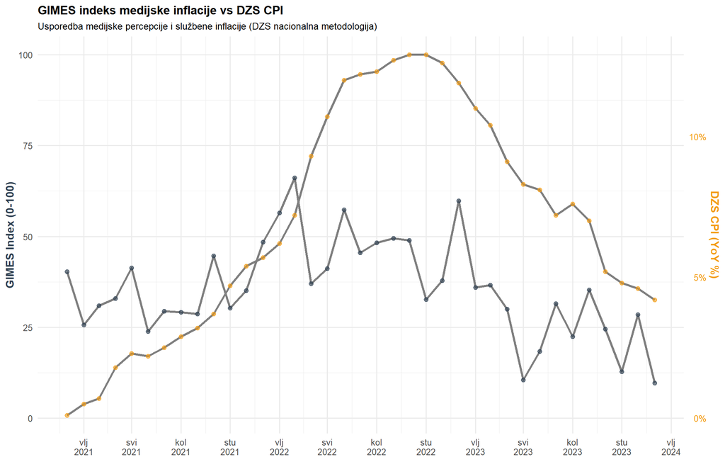

GIMES indeks vs DZS CPI inflacija

```r
coef_dzs <- 100 / max(comparison$dzs_cpi, na.rm = TRUE)

ggplot(comparison, aes(x = yearmonth)) +
  geom_line(aes(y = gimes_index, color = "GIMES Index"), linewidth = 1.2) +
  geom_point(aes(y = gimes_index), color = colors_gimes["primary"], size = 2, alpha = 0.6) +
  geom_line(aes(y = dzs_cpi * coef_dzs, color = "DZS CPI"),
            linewidth = 1.2, linetype = "solid") +
  geom_point(aes(y = dzs_cpi * coef_dzs), color = colors_gimes["warning"],
             size = 2, alpha = 0.6) +
  scale_y_continuous(
    name = "GIMES Index (0-100)",
    sec.axis = sec_axis(~./coef_dzs, name = "DZS CPI (YoY %)",
                       labels = function(x) paste0(x, "%"))
  ) +
  scale_x_date(date_breaks = "3 months", date_labels = "%b\n%Y") +
  scale_color_manual(values = c("GIMES Index" = colors_gimes["primary"],
                                "DZS CPI" = colors_gimes["warning"])) +
  labs(
    title = "GIMES indeks medijske inflacije vs DZS CPI",
    subtitle = "Usporedba medijske percepcije i službene inflacije (DZS nacionalna metodologija)",
    x = NULL,
    color = NULL
  ) +
  theme(
    plot.title = element_text(face = "bold", size = 13),
    plot.subtitle = element_text(size = 10),
    legend.position = "bottom",
    axis.title.y.right = element_text(color = colors_gimes["warning"], face = "bold"),
    axis.text.y.right = element_text(color = colors_gimes["warning"]),
    axis.title.y.left = element_text(color = colors_gimes["primary"], face = "bold")
  )
```

## 7.3 Dnevni broj članaka kao samostalni indikator vs službena inflacija

**Prikaži kod**

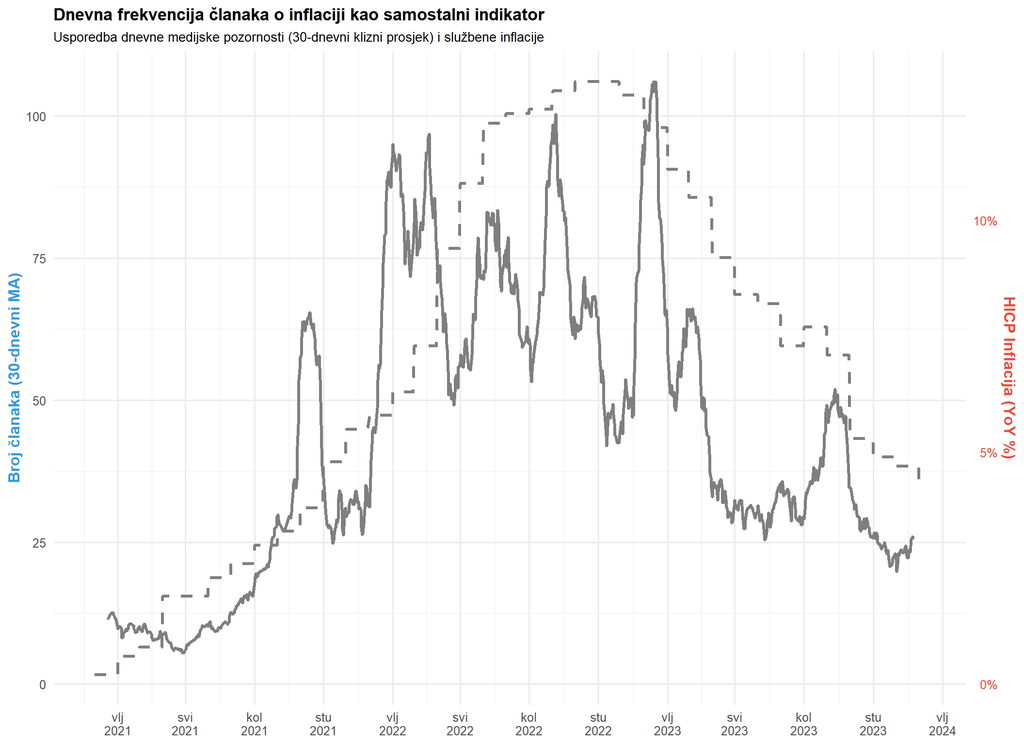

Dnevni broj članaka o inflaciji vs službena inflacija

```r
# Pripremi dnevne podatke sa inflacijom
daily_with_inflation <- merge(daily,
                              comparison[, .(yearmonth, eurostat_hicp)],
                              by.x = "date",
                              by.y = "yearmonth",
                              all.x = TRUE)

# Interpoliraj inflaciju za svaki dan
daily_with_inflation[, eurostat_hicp := zoo::na.locf(eurostat_hicp, na.rm = FALSE)]

coef_daily <- max(daily$MA30, na.rm = TRUE) / max(comparison$eurostat_hicp, na.rm = TRUE)

ggplot(daily_with_inflation[!is.na(eurostat_hicp)], aes(x = date)) +
  geom_line(aes(y = MA30, color = "30-dnevni prosjek članaka"), linewidth = 1.2, na.rm = TRUE) +
  geom_line(aes(y = eurostat_hicp * coef_daily, color = "Eurostat HICP"),
            linewidth = 1.2, linetype = "dashed") +
  scale_y_continuous(
    name = "Broj članaka (30-dnevni MA)",
    sec.axis = sec_axis(~./coef_daily, name = "HICP Inflacija (YoY %)",
                       labels = function(x) paste0(x, "%"))
  ) +
  scale_x_date(date_breaks = "3 months", date_labels = "%b\n%Y") +
  scale_color_manual(values = c("30-dnevni prosjek članaka" = colors_gimes["accent"],
                                "Eurostat HICP" = colors_gimes["secondary"])) +
  labs(
    title = "Dnevna frekvencija članaka o inflaciji kao samostalni indikator",
    subtitle = "Usporedba dnevne medijske pozornosti (30-dnevni klizni prosjek) i službene inflacije",
    x = NULL,
    color = NULL
  ) +
  theme(
    plot.title = element_text(face = "bold", size = 13),
    plot.subtitle = element_text(size = 10),
    legend.position = "bottom",
    axis.title.y.right = element_text(color = colors_gimes["secondary"], face = "bold"),
    axis.text.y.right = element_text(color = colors_gimes["secondary"]),
    axis.title.y.left = element_text(color = colors_gimes["accent"], face = "bold")
  )
```

## 7.4 Broj spominjanja riječi inflacija vs službena inflacija

**Prikaži kod**

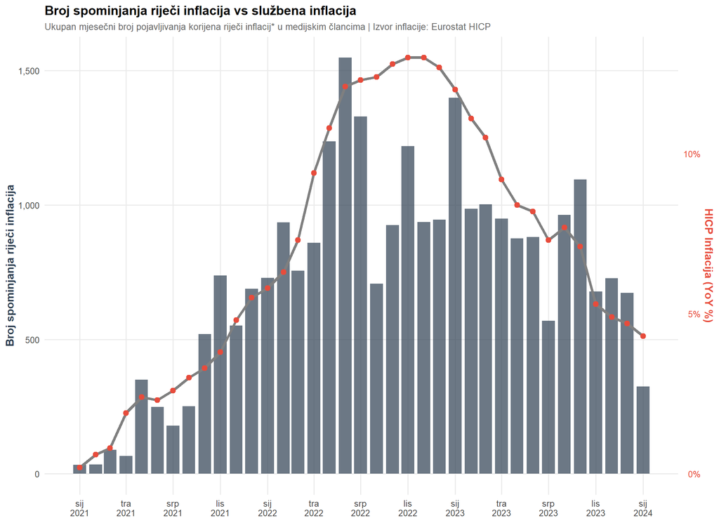

Mjesečni broj spominjanja riječi inflacija vs Eurostat HICP

```r
# Izbroji sve pojave korijena riječi "inflacij" u svakom članku
dt[, inflacija_count := stri_count_regex(tolower(FULL_TEXT), "inflacij[a-zčćžšđ]*")]

# Agregiraj po mjesecu
monthly_mentions <- dt[, .(
  total_mentions = sum(inflacija_count, na.rm = TRUE),
  avg_mentions_per_article = mean(inflacija_count, na.rm = TRUE),
  article_count = .N
), by = yearmonth][order(yearmonth)]

# Spoji s Eurostat podacima
monthly_mentions <- merge(monthly_mentions, eurostat_headline, by = "yearmonth", all.x = TRUE)

# Koeficijent za dual axis
coef_mentions <- max(monthly_mentions$total_mentions, na.rm = TRUE) /
                 max(monthly_mentions$eurostat_hicp, na.rm = TRUE)

ggplot(monthly_mentions, aes(x = yearmonth)) +
  geom_col(aes(y = total_mentions), fill = colors_gimes["primary"], alpha = 0.7, width = 25) +
  geom_line(aes(y = eurostat_hicp * coef_mentions, color = "Eurostat HICP"),
            linewidth = 1.5) +
  geom_point(aes(y = eurostat_hicp * coef_mentions),
             color = colors_gimes["secondary"], size = 2.5) +
  scale_y_continuous(
    name = "Broj spominjanja riječi inflacija",
    labels = comma,
    sec.axis = sec_axis(~./coef_mentions, name = "HICP Inflacija (YoY %)",
                       labels = function(x) paste0(x, "%"))
  ) +
  scale_x_date(date_breaks = "3 months", date_labels = "%b\n%Y") +
  scale_color_manual(values = c("Eurostat HICP" = colors_gimes["secondary"])) +
  labs(
    title = "Broj spominjanja riječi inflacija vs službena inflacija",
    subtitle = "Ukupan mjesečni broj pojavljivanja korijena riječi inflacij* u medijskim člancima | Izvor inflacije: Eurostat HICP",
    x = NULL,
    color = NULL
  ) +
  theme(
    plot.title = element_text(face = "bold", size = 14),
    plot.subtitle = element_text(size = 10, color = "gray40"),
    legend.position = "bottom",
    axis.title.y.right = element_text(color = colors_gimes["secondary"], face = "bold"),
    axis.text.y.right = element_text(color = colors_gimes["secondary"]),
    axis.title.y.left = element_text(color = colors_gimes["primary"], face = "bold"),
    panel.grid.minor = element_blank()
  )
```

## 7.5 Statistike spominjanja riječi inflacija

**Prikaži kod**

```r
word_stats <- data.table(
  Metrika = c(
    "Ukupan broj spominjanja riječi inflacija",
    "Prosječno spominjanja po članku",
    "Mjesec s najviše spominjanja",
    "Maksimalan broj spominjanja (mjesec)",
    "Korelacija s Eurostat HICP"
  ),
  Vrijednost = c(
    format(sum(dt$inflacija_count, na.rm = TRUE), big.mark = ","),
    round(mean(dt$inflacija_count, na.rm = TRUE), 2),
    format(monthly_mentions[which.max(total_mentions), yearmonth], "%B %Y"),
    format(max(monthly_mentions$total_mentions, na.rm = TRUE), big.mark = ","),
    round(cor(monthly_mentions$total_mentions, monthly_mentions$eurostat_hicp, use = "complete.obs"), 3)
  )
)

kable(word_stats, caption = "Statistike spominjanja riječi inflacija") %>%
  kable_styling(bootstrap_options = c("striped", "hover"), full_width = FALSE)
```

Statistike spominjanja riječi inflacija

| Metrika | Vrijednost |
| --- | --- |
| Ukupan broj spominjanja riječi inflacija | 27,005 |
| Prosječno spominjanja po članku | 0.59 |
| Mjesec s najviše spominjanja | lipanj 2022 |
| Maksimalan broj spominjanja (mjesec) | 1,548 |
| Korelacija s Eurostat HICP | 0.867 |

## 7.6 Korelacijska tablica

**Prikaži kod**

```r
correlations <- data.table(
  Usporedba = c(
    "GIMES Index vs Eurostat HICP",
    "GIMES Index vs Eurostat Core",
    "GIMES Index vs DZS CPI",
    "Volumen (broj članaka) vs Eurostat HICP"
  ),
  Korelacija = c(
    round(cor(comparison$gimes_index, comparison$eurostat_hicp, use = "complete.obs"), 3),
    round(cor(comparison$gimes_index, comparison$eurostat_core, use = "complete.obs"), 3),
    round(cor(comparison$gimes_index, comparison$dzs_cpi, use = "complete.obs"), 3),
    round(cor(comparison$volume, comparison$eurostat_hicp, use = "complete.obs"), 3)
  )
)

kable(correlations, caption = "Korelacije između različitih mjera inflacije") %>%
  kable_styling(bootstrap_options = c("striped", "hover"), full_width = FALSE) %>%
  row_spec(which.max(correlations$Korelacija), bold = TRUE, background = colors_gimes["success"])
```

Korelacije između različitih mjera inflacije

| Usporedba | Korelacija |
| --- | --- |
| GIMES Index vs Eurostat HICP | 0.392 |
| GIMES Index vs Eurostat Core | 0.210 |
| GIMES Index vs DZS CPI | 0.392 |
| Volumen (broj članaka) vs Eurostat HICP | 0.732 |

# 8 Analiza prediktivnosti

## 8.1 Cross-correlation analiza

**Prikaži kod**

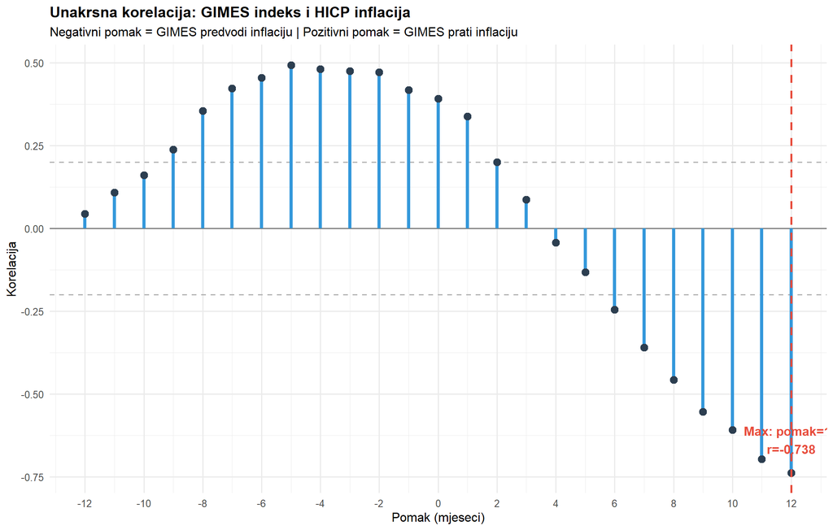

Unakrsna korelacija: GIMES vs HICP

```r
comparison_complete <- comparison[!is.na(gimes_index) & !is.na(eurostat_hicp)]

if(nrow(comparison_complete) >= 24) {
  ccf_result <- ccf(
    comparison_complete$gimes_index,
    comparison_complete$eurostat_hicp,
    lag.max = 12,
    plot = FALSE,
    na.action = na.pass
  )

  ccf_df <- data.table(
    lag = ccf_result$lag[,,1],
    correlation = ccf_result$acf[,,1]
  )

  max_corr <- ccf_df[which.max(abs(correlation))]

  ggplot(ccf_df, aes(x = lag, y = correlation)) +
    geom_hline(yintercept = 0, color = "gray50") +
    geom_hline(yintercept = c(-0.2, 0.2), linetype = "dashed", color = "gray70") +
    geom_segment(aes(xend = lag, yend = 0), linewidth = 1.5, color = colors_gimes["accent"]) +
    geom_point(size = 3, color = colors_gimes["primary"]) +
    geom_vline(xintercept = max_corr$lag, color = colors_gimes["secondary"],
               linetype = "dashed", linewidth = 1) +
    annotate("text", x = max_corr$lag, y = max_corr$correlation + 0.1,
             label = paste0("Max: pomak=", max_corr$lag,
                          "\nr=", round(max_corr$correlation, 3)),
             color = colors_gimes["secondary"], fontface = "bold") +
    scale_x_continuous(breaks = seq(-12, 12, 2)) +
    labs(
      title = "Unakrsna korelacija: GIMES indeks i HICP inflacija",
      subtitle = "Negativni pomak = GIMES predvodi inflaciju | Pozitivni pomak = GIMES prati inflaciju",
      x = "Pomak (mjeseci)",
      y = "Korelacija"
    ) +
    theme(plot.title = element_text(face = "bold"))
}
```

## 8.2 Korelacije s pomacima

**Prikaži kod**

```r
lags <- -6:6
correlations_lag <- sapply(lags, function(lag) {
  if(lag < 0) {
    x <- comparison$gimes_index[1:(nrow(comparison) + lag)]
    y <- comparison$eurostat_hicp[(abs(lag) + 1):nrow(comparison)]
  } else if(lag > 0) {
    x <- comparison$gimes_index[(lag + 1):nrow(comparison)]
    y <- comparison$eurostat_hicp[1:(nrow(comparison) - lag)]
  } else {
    x <- comparison$gimes_index
    y <- comparison$eurostat_hicp
  }
  cor(x, y, use = "complete.obs")
})

lag_table <- data.table(
  Pomak = lags,
  Opis = c(
    "GIMES -6 mjeseci",
    "GIMES -5 mjeseci",
    "GIMES -4 mjeseci",
    "GIMES -3 mjeseci",
    "GIMES -2 mjeseci",
    "GIMES -1 mjesec",
    "Istovremeno",
    "HICP -1 mjesec",
    "HICP -2 mjeseca",
    "HICP -3 mjeseca",
    "HICP -4 mjeseca",
    "HICP -5 mjeseci",
    "HICP -6 mjeseci"
  ),
  Korelacija = round(correlations_lag, 3)
)[order(-Korelacija)]

kable(lag_table,
      caption = "Korelacije GIMES indeksa i HICP inflacije sa različitim vremenskim pomacima",
      align = c("c", "l", "r")) %>%
  kable_styling(bootstrap_options = c("striped", "hover"), full_width = FALSE) %>%
  row_spec(which.max(lag_table$Korelacija), bold = TRUE, background = colors_gimes["success"])
```

Korelacije GIMES indeksa i HICP inflacije sa različitim vremenskim pomacima

| Pomak | Opis | Korelacija |
| --- | --- | --- |
| -5 | GIMES -5 mjeseci | 0.651 |
| -6 | GIMES -6 mjeseci | 0.620 |
| -4 | GIMES -4 mjeseci | 0.619 |
| -3 | GIMES -3 mjeseci | 0.590 |
| -2 | GIMES -2 mjeseci | 0.540 |
| -1 | GIMES -1 mjesec | 0.459 |
| 0 | Istovremeno | 0.392 |
| 1 | HICP -1 mjesec | 0.342 |
| 2 | HICP -2 mjeseca | 0.204 |
| 3 | HICP -3 mjeseca | 0.089 |
| 4 | HICP -4 mjeseca | -0.047 |
| 5 | HICP -5 mjeseci | -0.138 |
| 6 | HICP -6 mjeseci | -0.260 |

# 9 Zaključci i implikacije

## 9.1 Ključni nalazi

**Prikaži kod**

```r
peak_month <- index_data[which.max(gimes_index), yearmonth]
peak_value <- index_data[which.max(gimes_index), gimes_index]

peak_inflation_month <- comparison[which.max(eurostat_hicp), yearmonth]
peak_inflation_value <- comparison[which.max(eurostat_hicp), eurostat_hicp]

findings <- data.table(
  Nalaz = c(
    "Ukupno analiziranih članaka",
    "Vremenski raspon analize",
    "Broj izvora",
    "",
    "Vrh GIMES indeksa",
    "Vrijednost vrha",
    "",
    "Vrh inflacije (HICP)",
    "Vrijednost vrha",
    "",
    "Korelacija GIMES-HICP",
    "Optimalni pomak",
    "",
    "Prosječna duljina članka",
    "Dominantan sentiment"
  ),
  Vrijednost = c(
    format(nrow(dt), big.mark = ","),
    paste(format(min(dt$date), "%m/%Y"), "-", format(max(dt$date), "%m/%Y")),
    as.character(length(unique(dt$FROM))),
    "",
    format(peak_month, "%B %Y"),
    round(peak_value, 1),
    "",
    format(peak_inflation_month, "%B %Y"),
    paste0(round(peak_inflation_value, 1), "%"),
    "",
    round(cor(comparison$gimes_index, comparison$eurostat_hicp, use = "complete.obs"), 3),
    paste0(lags[which.max(abs(correlations_lag))], " mjeseci"),
    "",
    paste0(format(round(median(dt$text_length)), big.mark = ","), " znakova"),
    ifelse(sum(dt$AUTO_SENTIMENT == -1, na.rm = TRUE) > sum(dt$AUTO_SENTIMENT == 1, na.rm = TRUE),
           "Negativan", "Pozitivan/Neutralan")
  )
)

kable(findings, caption = "Sažetak ključnih nalaza analize") %>%
  kable_styling(bootstrap_options = c("striped", "hover"), full_width = FALSE) %>%
  row_spec(c(4, 7, 10, 13), background = colors_gimes["light"])
```

Sažetak ključnih nalaza analize

| Nalaz | Vrijednost |
| --- | --- |
| Ukupno analiziranih članaka | 46,107 |
| Vremenski raspon analize | 01/2021 - 01/2024 |
| Broj izvora | 115 |
| Vrh GIMES indeksa | ožujak 2022 |
| Vrijednost vrha | 66.1 |
| Vrh inflacije (HICP) | listopad 2022 |
| Vrijednost vrha | 13% |
| Korelacija GIMES-HICP | 0.392 |
| Optimalni pomak | -5 mjeseci |
| Prosječna duljina članka | 2,725 znakova |
| Dominantan sentiment | Negativan |

*Izvještaj generiran: 2025-12-23 14:12:27.71938*

*GIMES Istraživački projekt analize medijskog sadržaja*